# MV_Lab3

**Machine Vision Lab-3**

Vishwa R - 21BAI1772

Histogram Equalization, Translation and Rotation

```python
from PIL import Image as im
from matplotlib import pyplot as plt
import numpy as np
```

```
([], [])
```

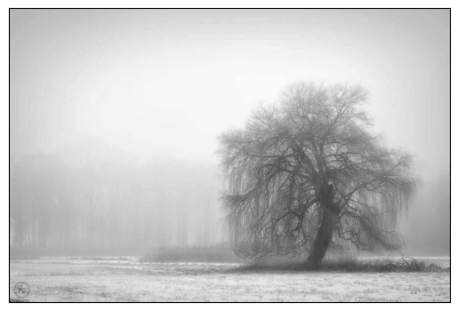

```python
img=im.open('tree.jpg')
grey_img=img.convert('L')
plt.imshow(grey_img,cmap='grey')
plt.xticks([])
plt.yticks([])
```

**Histogram Equalization**

In histogram equalization, the goal is to create a more uniform distribution of pixel intensities to enhance the contrast of the image

```python
img_arr=np.asarray(grey_img)
img_arr.shape
```

```
(733, 1100)
```

```python
hist=np.histogram(img_arr)
hist
```

```
(array([     2,     14,   6047,  33105,  47502,  56965,  79188, 181459,
        228718, 173300], dtype=int64),
 array([ 64. ,  81.8,  99.6, 117.4, 135.2, 153. , 170.8, 188.6, 206.4,
        224.2, 242. ]))
```

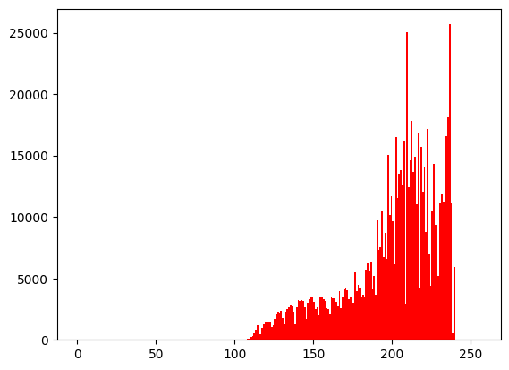

```python
flat=img_arr.flatten()
plt.hist(flat,256,[0,256],color='r')
plt.show()
```

```python
bins=256
histogram = np.zeros(bins)
for pixel in flat:    # loop through pixels and sum up counts of pixels
    histogram[pixel] += 1
hist = histogram
```

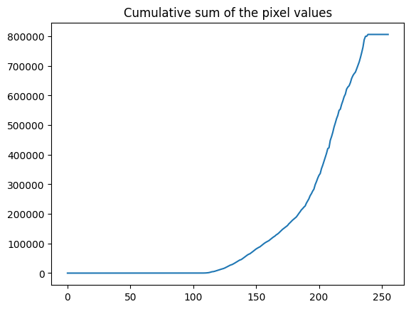

```python
a = iter(hist)
b = [next(a)]
for i in a:
    b.append(b[-1] + i)
cs=np.array(b)
plt.plot(cs)
plt.title("Cumulative sum of the pixel values")
```

As we can see the values are going above 255, we need to normalize

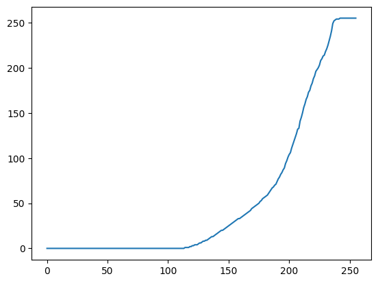

```python
cs = ((cs - cs.min()) * 255) / (cs.max() - cs.min())
cs = cs.astype('uint8')

plt.plot(cs)
```

Now all the values are within the required range

```python
img_new = cs[flat] #get the value from cumulative sum for every index in flat, and set that as img_new
```

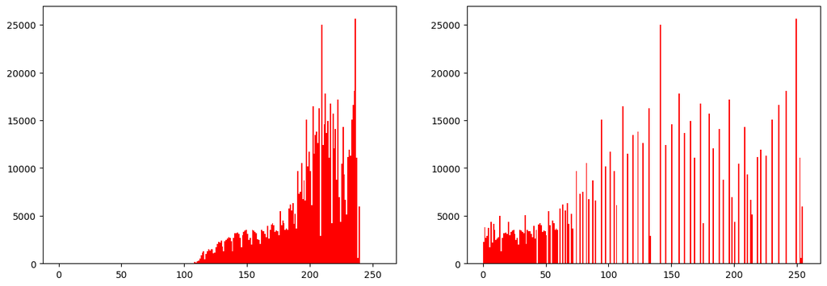

```python
img_new = np.reshape(img_new, np.asarray(grey_img).shape) #we flattened the image to compute, so now we resize it original image
fig = plt.figure()
fig.set_figheight(5)
fig.set_figwidth(15)

fig.add_subplot(1,2,1)
plt.hist(flat,256,[0,256],color='r')

fig.add_subplot(1,2,2)
plt.hist(img_new.ravel(),256,[0,256],color='r')

plt.show(block=True)
```

The histogram for a high contrast image(Right) spans the entire dynamic range, but the histogram for a low contrast image(Left) just covers a narrow range.

[figure not shown]

```python
fig = plt.figure()
fig.set_figheight(15)
fig.set_figwidth(15)

fig.add_subplot(1,2,1)
plt.imshow(grey_img, cmap='gray')
plt.xticks([])
plt.yticks([])

fig.add_subplot(1,2,2)
plt.imshow(img_new, cmap='gray')
plt.xticks([])
plt.yticks([])

plt.show(block=True)
```

As you can see we have successfully increased the contrast of the image. In the first image we can only see one tree but only when we increase the contrast, we can see that there's actually a lot of trees in the back

**Translation**

it is the shifting of an image along the x- and y-axis. It can shift an image up, down, left, or right, or any combination.

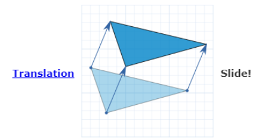

```
([], [])
```

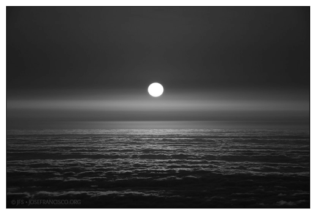

```python
img2=im.open("sun.jpg").convert('L')
plt.imshow(img2,cmap='grey')
img_arr2=np.asarray(img2)
plt.xticks([])
plt.yticks([])
```

```
([], [])
```

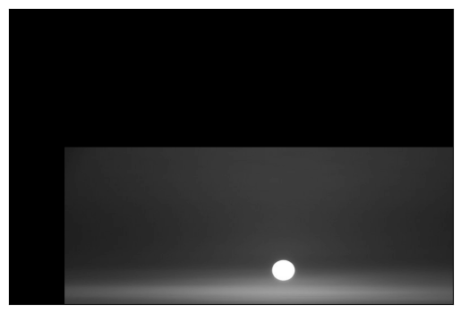

```python
tx=250
ty=100
trans_img=np.zeros_like(img_arr2)
r,c=img_arr2.shape
for x in range(r):
    for y in range(c):
        x_new=x+tx #translation
        y_new=y+ty
        if (0<=x_new<r) and (0<=y_new<c): #check if the values are within the range
            trans_img[x_new,y_new]=img_arr2[x,y]
plt.imshow(trans_img,cmap='grey')
plt.xticks([])
plt.yticks([])
```

```
([], [])
```

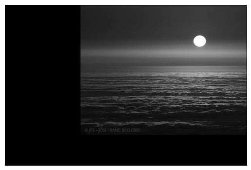

```python
tx=-100
ty=250
trans_img=np.zeros_like(img_arr2)
r,c=img_arr2.shape
for x in range(r):
    for y in range(c):
        x_new=x+tx #translation
        y_new=y+ty
        if (0<=x_new<r) and (0<=y_new<c): #check if the values are within the range
            trans_img[x_new,y_new]=img_arr2[x,y]
plt.imshow(trans_img,cmap='grey')
plt.xticks([])
plt.yticks([])
```

**Rotation**

it is a routine that takes an image, a rotation angle, and a point about which rotation is done.

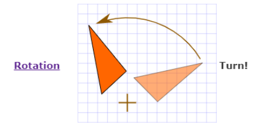

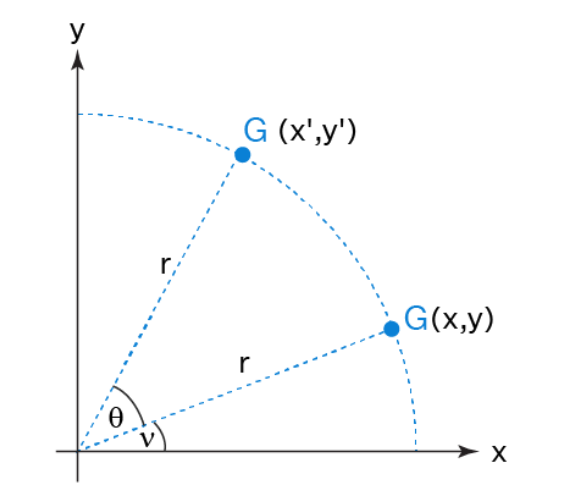

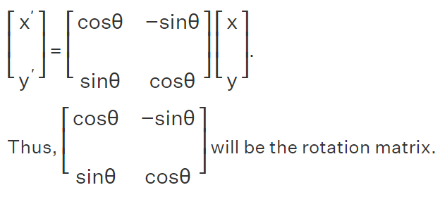

This is the rotation matrix for 2D Images

```
([], [])
```

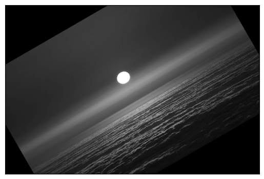

```python
angle = np.radians(30)
c_row, c_col = r // 2, c // 2 #centre of the image
rotate_image = np.zeros_like(img_arr2)
for i in range(r):
    for j in range(c):
        y = i - c_row #coordinates with respect to the centre
        x = j - c_col
        new_y = int(x * np.sin(angle) + y * np.cos(angle)) #this is the rotation matrix (multiplied with the x and y coordinates)
        new_x = int(x * np.cos(angle) - y * np.sin(angle)) #which helps us to rotate the image
        new_y += c_row #transform back to the original centre
        new_x += c_col
        if 0 <= new_x < c and 0 <= new_y < r: #check if the pixels values are within the range
            rotate_image[i, j] = img_arr2[new_y, new_x]
plt.imshow(rotate_image,cmap='grey')
plt.xticks([])
plt.yticks([])
```

```
([], [])
```

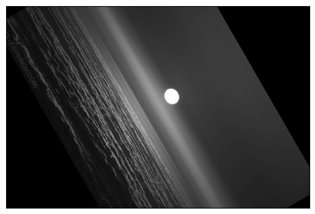

```python
angle = np.radians(-60)
c_row, c_col = r // 2, c // 2 #centre of the image
rotate_image = np.zeros_like(img_arr2)
for i in range(r):
    for j in range(c):
        y = i - c_row #coordinates with respect to the centre
        x = j - c_col
        new_y = int(x * np.sin(angle) + y * np.cos(angle)) #this is the rotation matrix (multiplied with the x and y coordinates)
        new_x = int(x * np.cos(angle) - y * np.sin(angle)) #which helps us to rotate the image
        new_y += c_row #transform back to the original centre
        new_x += c_col
        if 0 <= new_x < c and 0 <= new_y < r: #check if the pixels values are within the range
            rotate_image[i, j] = img_arr2[new_y, new_x]
plt.imshow(rotate_image,cmap='grey')
plt.xticks([])
plt.yticks([])
```

We have successfully rotated the image with 2 different degrees: 30 degrees and -60 degrees

==========================================================================================